# project ( movies )

```python
import pandas as pd
import numpy as np
import matplotlib.pyplot as plt
```

## TMDB Movies Dataset Description

This dataset contains information about movies from The Movie Database (TMDB). It includes details such as movie titles, release dates, budgets, revenues, ratings, and more.

### Main Columns:

1. **id**: Unique identifier for the movie.
2. **imdb_id**: Unique identifier for the movie in IMDb.
3. **popularity**: A numeric value representing the movie's popularity.
4. **budget**: The budget of the movie (in USD).
5. **revenue**: The revenue generated by the movie (in USD).
6. **original_title**: The original title of the movie.
7. **cast**: A list of actors/actresses in the movie.
8. **homepage**: The official homepage of the movie (if available).
9. **director**: The director of the movie.
10. **tagline**: A short tagline or slogan for the movie.
11. **keywords**: Keywords or tags associated with the movie.
12. **overview**: A brief summary or description of the movie.
13. **runtime**: The duration of the movie (in minutes).
14. **genres**: A list of genres the movie belongs to (e.g., Action, Drama, Comedy).
15. **production_companies**: A list of companies involved in the movie's production.
16. **release_date**: The release date of the movie.
17. **vote_count**: The number of votes the movie received.
18. **vote_average**: The average rating of the movie (out of 10).
19. **release_year**: The year the movie was released (extracted from release_date).

### Initial Data Exploration

```python
df= pd.read_csv('tmdb-movies.csv')
# read the first 5 rows in the data
df.head(5)
```

|  | id | imdb_id | popularity | budget | revenue | original_title | cast | homepage | director | tagline | ... | overview | runtime | genres | production_companies | release_date | vote_count | vote_average | release_year | budget_adj | revenue_adj |
| --- | --- | --- | --- | --- | --- | --- | --- | --- | --- | --- | --- | --- | --- | --- | --- | --- | --- | --- | --- | --- | --- |
| 0 | 135397 | tt0369610 | 32.985763 | 150000000 | 1513528810 | Jurassic World | Chris Pratt\|Bryce Dallas Howard\|Irrfan Khan\|Vi... | http://www.jurassicworld.com/ | Colin Trevorrow | The park is open. | ... | Twenty-two years after the events of Jurassic ... | 124 | Action\|Adventure\|Science Fiction\|Thriller | Universal Studios\|Amblin Entertainment\|Legenda... | 6/9/15 | 5562 | 6.5 | 2015 | 1.379999e+08 | 1.392446e+09 |
| 1 | 76341 | tt1392190 | 28.419936 | 150000000 | 378436354 | Mad Max: Fury Road | Tom Hardy\|Charlize Theron\|Hugh Keays-Byrne\|Nic... | http://www.madmaxmovie.com/ | George Miller | What a Lovely Day. | ... | An apocalyptic story set in the furthest reach... | 120 | Action\|Adventure\|Science Fiction\|Thriller | Village Roadshow Pictures\|Kennedy Miller Produ... | 5/13/15 | 6185 | 7.1 | 2015 | 1.379999e+08 | 3.481613e+08 |
| 2 | 262500 | tt2908446 | 13.112507 | 110000000 | 295238201 | Insurgent | Shailene Woodley\|Theo James\|Kate Winslet\|Ansel... | http://www.thedivergentseries.movie/#insurgent | Robert Schwentke | One Choice Can Destroy You | ... | Beatrice Prior must confront her inner demons ... | 119 | Adventure\|Science Fiction\|Thriller | Summit Entertainment\|Mandeville Films\|Red Wago... | 3/18/15 | 2480 | 6.3 | 2015 | 1.012000e+08 | 2.716190e+08 |
| 3 | 140607 | tt2488496 | 11.173104 | 200000000 | 2068178225 | Star Wars: The Force Awakens | Harrison Ford\|Mark Hamill\|Carrie Fisher\|Adam D... | http://www.starwars.com/films/star-wars-episod... | J.J. Abrams | Every generation has a story. | ... | Thirty years after defeating the Galactic Empi... | 136 | Action\|Adventure\|Science Fiction\|Fantasy | Lucasfilm\|Truenorth Productions\|Bad Robot | 12/15/15 | 5292 | 7.5 | 2015 | 1.839999e+08 | 1.902723e+09 |
| 4 | 168259 | tt2820852 | 9.335014 | 190000000 | 1506249360 | Furious 7 | Vin Diesel\|Paul Walker\|Jason Statham\|Michelle ... | http://www.furious7.com/ | James Wan | Vengeance Hits Home | ... | Deckard Shaw seeks revenge against Dominic Tor... | 137 | Action\|Crime\|Thriller | Universal Pictures\|Original Film\|Media Rights ... | 4/1/15 | 2947 | 7.3 | 2015 | 1.747999e+08 | 1.385749e+09 |

5 rows × 21 columns

```python
# read the least 5 rows in the data
df.tail(5)
```

|  | id | imdb_id | popularity | budget | revenue | original_title | cast | homepage | director | tagline | ... | overview | runtime | genres | production_companies | release_date | vote_count | vote_average | release_year | budget_adj | revenue_adj |
| --- | --- | --- | --- | --- | --- | --- | --- | --- | --- | --- | --- | --- | --- | --- | --- | --- | --- | --- | --- | --- | --- |
| 10861 | 21 | tt0060371 | 0.080598 | 0 | 0 | The Endless Summer | Michael Hynson\|Robert August\|Lord 'Tally Ho' B... | NaN | Bruce Brown | NaN | ... | The Endless Summer, by Bruce Brown, is one of ... | 95 | Documentary | Bruce Brown Films | 6/15/66 | 11 | 7.4 | 1966 | 0.000000 | 0.0 |
| 10862 | 20379 | tt0060472 | 0.065543 | 0 | 0 | Grand Prix | James Garner\|Eva Marie Saint\|Yves Montand\|Tosh... | NaN | John Frankenheimer | Cinerama sweeps YOU into a drama of speed and ... | ... | Grand Prix driver Pete Aron is fired by his te... | 176 | Action\|Adventure\|Drama | Cherokee Productions\|Joel Productions\|Douglas ... | 12/21/66 | 20 | 5.7 | 1966 | 0.000000 | 0.0 |
| 10863 | 39768 | tt0060161 | 0.065141 | 0 | 0 | Beregis Avtomobilya | Innokentiy Smoktunovskiy\|Oleg Efremov\|Georgi Z... | NaN | Eldar Ryazanov | NaN | ... | An insurance agent who moonlights as a carthie... | 94 | Mystery\|Comedy | Mosfilm | 1/1/66 | 11 | 6.5 | 1966 | 0.000000 | 0.0 |
| 10864 | 21449 | tt0061177 | 0.064317 | 0 | 0 | What's Up, Tiger Lily? | Tatsuya Mihashi\|Akiko Wakabayashi\|Mie Hama\|Joh... | NaN | Woody Allen | WOODY ALLEN STRIKES BACK! | ... | In comic Woody Allen's film debut, he took the... | 80 | Action\|Comedy | Benedict Pictures Corp. | 11/2/66 | 22 | 5.4 | 1966 | 0.000000 | 0.0 |
| 10865 | 22293 | tt0060666 | 0.035919 | 19000 | 0 | Manos: The Hands of Fate | Harold P. Warren\|Tom Neyman\|John Reynolds\|Dian... | NaN | Harold P. Warren | It's Shocking! It's Beyond Your Imagination! | ... | A family gets lost on the road and stumbles up... | 74 | Horror | Norm-Iris | 11/15/66 | 15 | 1.5 | 1966 | 127642.279154 | 0.0 |

5 rows × 21 columns

```python
# Basic statistics about the dataset:
print("\nBasic statistics about the dataset:")
df.describe()
```

```
Basic statistics about the dataset:
```

|  | id | popularity | budget | revenue | runtime | vote_count | vote_average | release_year | budget_adj | revenue_adj |
| --- | --- | --- | --- | --- | --- | --- | --- | --- | --- | --- |
| count | 10866.000000 | 10866.000000 | 1.086600e+04 | 1.086600e+04 | 10866.000000 | 10866.000000 | 10866.000000 | 10866.000000 | 1.086600e+04 | 1.086600e+04 |
| mean | 66064.177434 | 0.646441 | 1.462570e+07 | 3.982332e+07 | 102.070863 | 217.389748 | 5.974922 | 2001.322658 | 1.755104e+07 | 5.136436e+07 |
| std | 92130.136561 | 1.000185 | 3.091321e+07 | 1.170035e+08 | 31.381405 | 575.619058 | 0.935142 | 12.812941 | 3.430616e+07 | 1.446325e+08 |
| min | 5.000000 | 0.000065 | 0.000000e+00 | 0.000000e+00 | 0.000000 | 10.000000 | 1.500000 | 1960.000000 | 0.000000e+00 | 0.000000e+00 |
| 25% | 10596.250000 | 0.207583 | 0.000000e+00 | 0.000000e+00 | 90.000000 | 17.000000 | 5.400000 | 1995.000000 | 0.000000e+00 | 0.000000e+00 |
| 50% | 20669.000000 | 0.383856 | 0.000000e+00 | 0.000000e+00 | 99.000000 | 38.000000 | 6.000000 | 2006.000000 | 0.000000e+00 | 0.000000e+00 |
| 75% | 75610.000000 | 0.713817 | 1.500000e+07 | 2.400000e+07 | 111.000000 | 145.750000 | 6.600000 | 2011.000000 | 2.085325e+07 | 3.369710e+07 |
| max | 417859.000000 | 32.985763 | 4.250000e+08 | 2.781506e+09 | 900.000000 | 9767.000000 | 9.200000 | 2015.000000 | 4.250000e+08 | 2.827124e+09 |

```python
print("\nSize of the dataset (rows, columns):")
df.shape
```

```
Size of the dataset (rows, columns):
```

```
(10866, 21)
```

```python
df.info()
```

```
<class 'pandas.core.frame.DataFrame'>
RangeIndex: 10866 entries, 0 to 10865
Data columns (total 21 columns):
 #   Column                Non-Null Count  Dtype
---  ------                --------------  -----
 0   id                    10866 non-null  int64
 1   imdb_id               10856 non-null  object
 2   popularity            10866 non-null  float64
 3   budget                10866 non-null  int64
 4   revenue               10866 non-null  int64
 5   original_title        10866 non-null  object
 6   cast                  10790 non-null  object
 7   homepage              2936 non-null   object
 8   director              10822 non-null  object
 9   tagline               8042 non-null   object
 10  keywords              9373 non-null   object
 11  overview              10862 non-null  object
 12  runtime               10866 non-null  int64
 13  genres                10843 non-null  object
 14  production_companies  9836 non-null   object
 15  release_date          10866 non-null  object
 16  vote_count            10866 non-null  int64
 17  vote_average          10866 non-null  float64
 18  release_year          10866 non-null  int64
 19  budget_adj            10866 non-null  float64
 20  revenue_adj           10866 non-null  float64
dtypes: float64(4), int64(6), object(11)
memory usage: 1.7+ MB
```

```python
# Missing values
print("\nMissing values in each column:")
df.isnull().sum()
```

```
Missing values in each column:
```

```
id                         0
imdb_id                   10
popularity                 0
budget                     0
revenue                    0
original_title             0
cast                      76
homepage                7930
director                  44
tagline                 2824
keywords                1493
overview                   4
runtime                    0
genres                    23
production_companies    1030
release_date               0
vote_count                 0
vote_average               0
release_year               0
budget_adj                 0
revenue_adj                0
dtype: int64
```

## Clean the Data

#### Drop unnecessary columns :(

```python
df.drop(['homepage', 'tagline', 'keywords', 'overview', 'imdb_id','production_companies'], axis = 1, inplace = True)
```

```python
df.head()
```

|  | id | popularity | budget | revenue | original_title | cast | director | runtime | genres | release_date | vote_count | vote_average | release_year | budget_adj | revenue_adj |
| --- | --- | --- | --- | --- | --- | --- | --- | --- | --- | --- | --- | --- | --- | --- | --- |
| 0 | 135397 | 32.985763 | 150000000 | 1513528810 | Jurassic World | Chris Pratt\|Bryce Dallas Howard\|Irrfan Khan\|Vi... | Colin Trevorrow | 124 | Action\|Adventure\|Science Fiction\|Thriller | 6/9/15 | 5562 | 6.5 | 2015 | 1.379999e+08 | 1.392446e+09 |
| 1 | 76341 | 28.419936 | 150000000 | 378436354 | Mad Max: Fury Road | Tom Hardy\|Charlize Theron\|Hugh Keays-Byrne\|Nic... | George Miller | 120 | Action\|Adventure\|Science Fiction\|Thriller | 5/13/15 | 6185 | 7.1 | 2015 | 1.379999e+08 | 3.481613e+08 |
| 2 | 262500 | 13.112507 | 110000000 | 295238201 | Insurgent | Shailene Woodley\|Theo James\|Kate Winslet\|Ansel... | Robert Schwentke | 119 | Adventure\|Science Fiction\|Thriller | 3/18/15 | 2480 | 6.3 | 2015 | 1.012000e+08 | 2.716190e+08 |
| 3 | 140607 | 11.173104 | 200000000 | 2068178225 | Star Wars: The Force Awakens | Harrison Ford\|Mark Hamill\|Carrie Fisher\|Adam D... | J.J. Abrams | 136 | Action\|Adventure\|Science Fiction\|Fantasy | 12/15/15 | 5292 | 7.5 | 2015 | 1.839999e+08 | 1.902723e+09 |
| 4 | 168259 | 9.335014 | 190000000 | 1506249360 | Furious 7 | Vin Diesel\|Paul Walker\|Jason Statham\|Michelle ... | James Wan | 137 | Action\|Crime\|Thriller | 4/1/15 | 2947 | 7.3 | 2015 | 1.747999e+08 | 1.385749e+09 |

#### Fill missing values in (vote_average) with the mean

```python
# As 'vote_average' is numerical column so... fill the null values withe the mean :)
df['vote_average'].fillna(df['vote_average'].mean(), inplace=True)
```

```python
df.info()
```

```
<class 'pandas.core.frame.DataFrame'>
RangeIndex: 10866 entries, 0 to 10865
Data columns (total 15 columns):
 #   Column          Non-Null Count  Dtype
---  ------          --------------  -----
 0   id              10866 non-null  int64
 1   popularity      10866 non-null  float64
 2   budget          10866 non-null  int64
 3   revenue         10866 non-null  int64
 4   original_title  10866 non-null  object
 5   cast            10790 non-null  object
 6   director        10822 non-null  object
 7   runtime         10866 non-null  int64
 8   genres          10843 non-null  object
 9   release_date    10866 non-null  object
 10  vote_count      10866 non-null  int64
 11  vote_average    10866 non-null  float64
 12  release_year    10866 non-null  int64
 13  budget_adj      10866 non-null  float64
 14  revenue_adj     10866 non-null  float64
dtypes: float64(4), int64(6), object(5)
memory usage: 1.2+ MB
```

#### Drop rows with missing values (important columns) :)

```python
df = df.dropna(subset=['genres', 'revenue','director'])
```

```python
df.info()
```

```
<class 'pandas.core.frame.DataFrame'>
Index: 10801 entries, 0 to 10865
Data columns (total 15 columns):
 #   Column          Non-Null Count  Dtype
---  ------          --------------  -----
 0   id              10801 non-null  int64
 1   popularity      10801 non-null  float64
 2   budget          10801 non-null  int64
 3   revenue         10801 non-null  int64
 4   original_title  10801 non-null  object
 5   cast            10732 non-null  object
 6   director        10801 non-null  object
 7   runtime         10801 non-null  int64
 8   genres          10801 non-null  object
 9   release_date    10801 non-null  object
 10  vote_count      10801 non-null  int64
 11  vote_average    10801 non-null  float64
 12  release_year    10801 non-null  int64
 13  budget_adj      10801 non-null  float64
 14  revenue_adj     10801 non-null  float64
dtypes: float64(4), int64(6), object(5)
memory usage: 1.3+ MB
```

## What is the most popular genery from year to year :) ?

```python
df.head()
```

|  | id | popularity | budget | revenue | original_title | cast | director | runtime | genres | release_date | vote_count | vote_average | release_year | budget_adj | revenue_adj |
| --- | --- | --- | --- | --- | --- | --- | --- | --- | --- | --- | --- | --- | --- | --- | --- |
| 0 | 135397 | 32.985763 | 150000000 | 1513528810 | Jurassic World | Chris Pratt\|Bryce Dallas Howard\|Irrfan Khan\|Vi... | Colin Trevorrow | 124 | Action\|Adventure\|Science Fiction\|Thriller | 6/9/15 | 5562 | 6.5 | 2015 | 1.379999e+08 | 1.392446e+09 |
| 1 | 76341 | 28.419936 | 150000000 | 378436354 | Mad Max: Fury Road | Tom Hardy\|Charlize Theron\|Hugh Keays-Byrne\|Nic... | George Miller | 120 | Action\|Adventure\|Science Fiction\|Thriller | 5/13/15 | 6185 | 7.1 | 2015 | 1.379999e+08 | 3.481613e+08 |
| 2 | 262500 | 13.112507 | 110000000 | 295238201 | Insurgent | Shailene Woodley\|Theo James\|Kate Winslet\|Ansel... | Robert Schwentke | 119 | Adventure\|Science Fiction\|Thriller | 3/18/15 | 2480 | 6.3 | 2015 | 1.012000e+08 | 2.716190e+08 |
| 3 | 140607 | 11.173104 | 200000000 | 2068178225 | Star Wars: The Force Awakens | Harrison Ford\|Mark Hamill\|Carrie Fisher\|Adam D... | J.J. Abrams | 136 | Action\|Adventure\|Science Fiction\|Fantasy | 12/15/15 | 5292 | 7.5 | 2015 | 1.839999e+08 | 1.902723e+09 |
| 4 | 168259 | 9.335014 | 190000000 | 1506249360 | Furious 7 | Vin Diesel\|Paul Walker\|Jason Statham\|Michelle ... | James Wan | 137 | Action\|Crime\|Thriller | 4/1/15 | 2947 | 7.3 | 2015 | 1.747999e+08 | 1.385749e+09 |

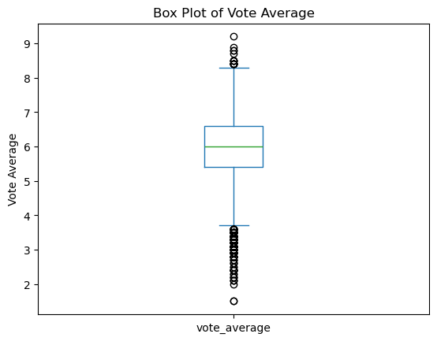

```python
# Making Box Plot for column : vote_average
df['vote_average'].plot(kind='box', title='Box Plot of Vote Average')
plt.ylabel('Vote Average')
plt.show()
```

```python
df['genres']
```

```
0        Action|Adventure|Science Fiction|Thriller
1        Action|Adventure|Science Fiction|Thriller
2               Adventure|Science Fiction|Thriller
3         Action|Adventure|Science Fiction|Fantasy
4                            Action|Crime|Thriller
                           ...
10861                                  Documentary
10862                       Action|Adventure|Drama
10863                               Mystery|Comedy
10864                                Action|Comedy
10865                                       Horror
Name: genres, Length: 10801, dtype: object
```

```python
# function to find the most popular genres for each release year.
def get_most_popular_genres(df):
    df['genres'] = df['genres'].str.split('|')
    genres_df = df.explode('genres')
    genres_popularity = genres_df.groupby(['release_year', 'genres']).size().unstack()
    top_popular_genres = genres_popularity.idxmax(axis=1)
    most_popular_genres= get_most_popular_genres(df)
```

[output not shown]

### The most popular genery from year to year

```python
print('\nThe most popular genery from year to year')
pd.DataFrame(most_popular_genres)
```

```
The most popular genery from year to year
```

[output not shown]

### Count the number of movies per genre

```python
# 1d ..............
genre_counts = genres_df['genres'].value_counts()
print("\nThe sum of movies in each genre the : ")
genre_counts
```

```
The sum of movies in each genre the :
```

```
genres
Drama              4755
Comedy             3782
Thriller           2905
Action             2379
Romance            1708
Horror             1636
Adventure          1466
Crime              1354
Science Fiction    1224
Family             1223
Fantasy             912
Mystery             809
Animation           692
Documentary         509
Music               402
History             332
War                 270
Foreign             185
Western             164
TV Movie            162
Name: count, dtype: int64
```

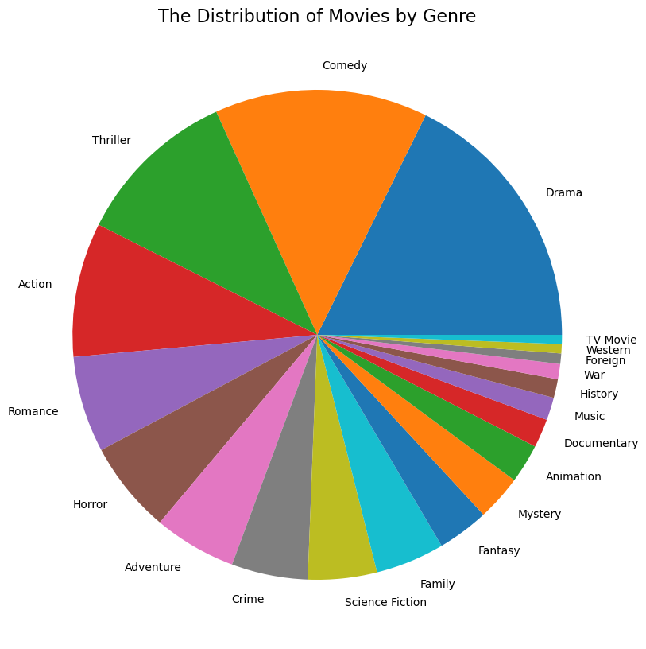

```python
plt.figure(figsize=(15, 10))
plt.pie(genre_counts, labels= genre_counts.index)
plt.title('The Distribution of Movies by Genre', fontsize=16)
plt.show()
```

### Calculate the average revenue per genre

```python
df.head()
```

|  | id | popularity | budget | revenue | original_title | cast | director | runtime | genres | release_date | vote_count | vote_average | release_year | budget_adj | revenue_adj |
| --- | --- | --- | --- | --- | --- | --- | --- | --- | --- | --- | --- | --- | --- | --- | --- |
| 0 | 135397 | 32.985763 | 150000000 | 1513528810 | Jurassic World | Chris Pratt\|Bryce Dallas Howard\|Irrfan Khan\|Vi... | Colin Trevorrow | 124 | Action\|Adventure\|Science Fiction\|Thriller | 6/9/15 | 5562 | 6.5 | 2015 | 1.379999e+08 | 1.392446e+09 |
| 1 | 76341 | 28.419936 | 150000000 | 378436354 | Mad Max: Fury Road | Tom Hardy\|Charlize Theron\|Hugh Keays-Byrne\|Nic... | George Miller | 120 | Action\|Adventure\|Science Fiction\|Thriller | 5/13/15 | 6185 | 7.1 | 2015 | 1.379999e+08 | 3.481613e+08 |
| 2 | 262500 | 13.112507 | 110000000 | 295238201 | Insurgent | Shailene Woodley\|Theo James\|Kate Winslet\|Ansel... | Robert Schwentke | 119 | Adventure\|Science Fiction\|Thriller | 3/18/15 | 2480 | 6.3 | 2015 | 1.012000e+08 | 2.716190e+08 |
| 3 | 140607 | 11.173104 | 200000000 | 2068178225 | Star Wars: The Force Awakens | Harrison Ford\|Mark Hamill\|Carrie Fisher\|Adam D... | J.J. Abrams | 136 | Action\|Adventure\|Science Fiction\|Fantasy | 12/15/15 | 5292 | 7.5 | 2015 | 1.839999e+08 | 1.902723e+09 |
| 4 | 168259 | 9.335014 | 190000000 | 1506249360 | Furious 7 | Vin Diesel\|Paul Walker\|Jason Statham\|Michelle ... | James Wan | 137 | Action\|Crime\|Thriller | 4/1/15 | 2947 | 7.3 | 2015 | 1.747999e+08 | 1.385749e+09 |

```python
avg_revenue_per_genre = genres_df.groupby('genres')['revenue'].mean().sort_values(ascending=False)
```

```python
pd.DataFrame(avg_revenue_per_genre)
```

| genres | revenue |
| --- | --- |
| Adventure | 1.135237e+08 |
| Fantasy | 9.673609e+07 |
| Animation | 7.601732e+07 |
| Action | 7.294813e+07 |
| Family | 7.290698e+07 |
| Science Fiction | 7.042787e+07 |
| War | 4.760518e+07 |
| Crime | 4.236938e+07 |
| Thriller | 4.175748e+07 |
| Mystery | 4.026728e+07 |
| Comedy | 3.763248e+07 |
| Romance | 3.576912e+07 |
| History | 3.220464e+07 |
| Drama | 2.926088e+07 |
| Music | 2.899821e+07 |
| Western | 2.874291e+07 |
| Horror | 1.683309e+07 |
| Documentary | 2.085217e+06 |
| Foreign | 1.485656e+06 |
| TV Movie | 2.592593e+05 |

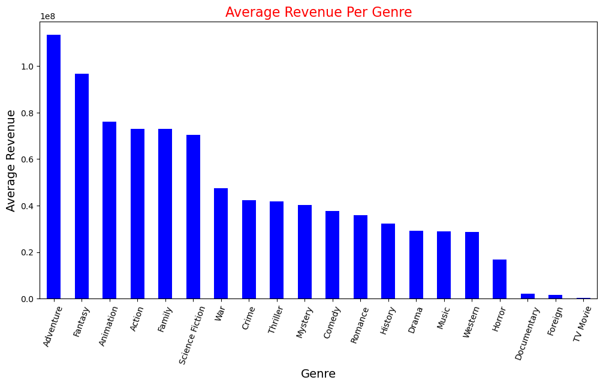

```python
avg_revenue_per_genre.plot(kind='bar', figsize=(12, 6), color='blue')
plt.title('Average Revenue Per Genre', fontsize=16, color='red')
plt.xlabel('Genre', fontsize=14)
plt.ylabel('Average Revenue', fontsize=14)
plt.xticks(rotation=70)
plt.show()
```

### Top 3 Directors according their revenues :)

```python
avg_revenue_per_director= df.groupby('director')['revenue'].mean().sort_values(ascending=False).head(3)
```

```python
pd.DataFrame(avg_revenue_per_director)
```

| director | revenue |
| --- | --- |
| Kyle Balda\|Pierre Coffin | 1.156731e+09 |
| Lee Unkrich | 1.063172e+09 |
| Andrew Adamson\|Kelly Asbury\|Conrad Vernon | 9.198388e+08 |

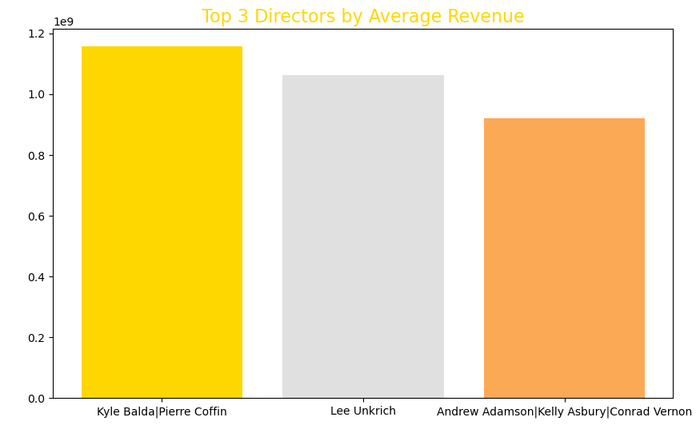

```python
plt.figure(figsize=(10, 6))
plt.bar(avg_revenue_per_director.index, avg_revenue_per_director.values, color=['#FFD700', '#e0e0e0', '#fca956'])
plt.title('Top 3 Directors by Average Revenue', fontsize=16,color='#FFD700')
plt.xlabel('Director', fontsize=14, color='white')
plt.ylabel('Average Revenue', fontsize=14, color='white')
plt.show()
```

### Highest-rated movies.

```python
print("\nTop 3 movies by rating:")
# make var. top_3_ratings that contain (top 3) ... of  df: ('original_title', 'release_year', 'vote_average') and sorted according to 'vote_average'
top_3_ratings = df[['original_title', 'release_year', 'vote_average']].sort_values(by='vote_average', ascending=False).head(3)
pd.DataFrame(top_3_ratings)
```

```
Top 3 movies by rating:
```

|  | original_title | release_year | vote_average |
| --- | --- | --- | --- |
| 3894 | The Story of Film: An Odyssey | 2011 | 9.2 |
| 538 | The Mask You Live In | 2015 | 8.9 |
| 2269 | Life Cycles | 2010 | 8.8 |

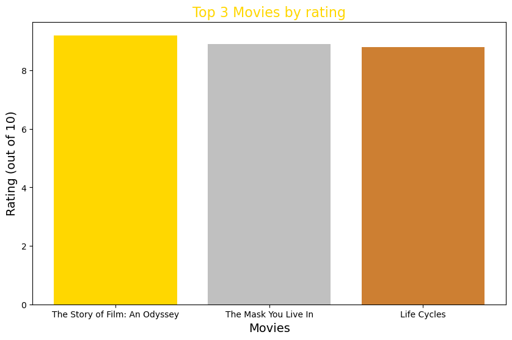

```python
plt.figure(figsize=(10, 6))
plt.bar(top_3_ratings['original_title'], top_3_ratings['vote_average'], color=['#FFD700', '#C0C0C0', '#CD7F32'])
plt.title('Top 3 Movies by rating', fontsize=16, color='#FFD700')
plt.xlabel('Movies', fontsize=14, color='black')
plt.ylabel('Rating (out of 10)', fontsize=14, color='black')
plt.show()
```

```python
# Define high-revenue movies (top 5%)
revenue_comp = np.percentile(df['revenue'], 95)  # 95th percentile by (numpy)
high_revenue_movies = df[df['revenue'] > revenue_comp]
other_movies = df[df['revenue'] <= revenue_comp]
```

### Compare properties of high-revenue movies vs others

```python
print("Properties of High-Revenue Movies:")
print(high_revenue_movies[['budget', 'vote_average', 'popularity', 'runtime']].describe())

print("\nProperties of Other Movies:")
print(other_movies[['budget', 'vote_average', 'popularity', 'runtime']].describe())
```

```
Properties of High-Revenue Movies:
             budget  vote_average  popularity     runtime
count  5.400000e+02    540.000000  540.000000  540.000000
mean   9.800699e+07      6.512222    2.914378  117.885185
std    6.154738e+07      0.709123    2.829072   22.256011
min    0.000000e+00      4.400000    0.131526   79.000000
25%    5.000000e+07      6.000000    1.445801  100.000000
50%    9.000000e+07      6.500000    2.199646  116.000000
75%    1.400000e+08      7.000000    3.461242  131.000000
max    3.800000e+08      8.300000   32.985763  201.000000

Properties of Other Movies:
             budget  vote_average    popularity       runtime
count  1.026100e+04  10261.000000  10261.000000  10261.000000
mean   1.032906e+07      5.942296      0.530255    101.362733
std    2.067047e+07      0.934701      0.594148     30.947849
min    0.000000e+00      1.500000      0.000188      0.000000
25%    0.000000e+00      5.400000      0.202017     90.000000
50%    0.000000e+00      6.000000      0.364854     98.000000
75%    1.200000e+07      6.600000      0.642207    110.000000
max    4.250000e+08      9.200000     11.422751    900.000000
```

## high revenue movies VS Other Movies

- that high revenue movies have significantly higher budgets.
- High high revenue movies have higher average ratings.
- High high revenue movies are more popular.
- High high revenue movies are slightly longer in duration.

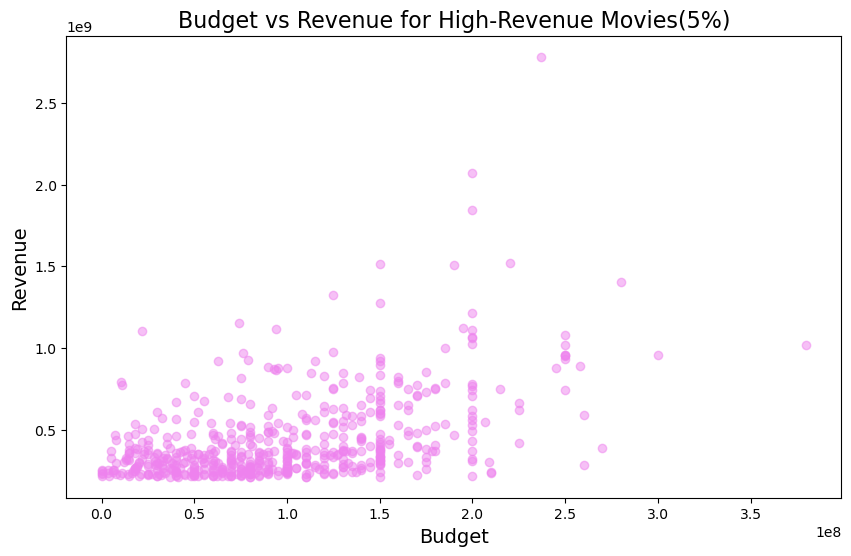

```python
# Plot the relationship between budget and revenue
plt.figure(figsize=(10, 6))
plt.scatter(high_revenue_movies['budget'], high_revenue_movies['revenue'], alpha=0.5, color='violet')
plt.title('Budget vs Revenue for High-Revenue Movies(5%)', fontsize=16)
plt.xlabel('Budget', fontsize=14)
plt.ylabel('Revenue', fontsize=14)
plt.show()
```

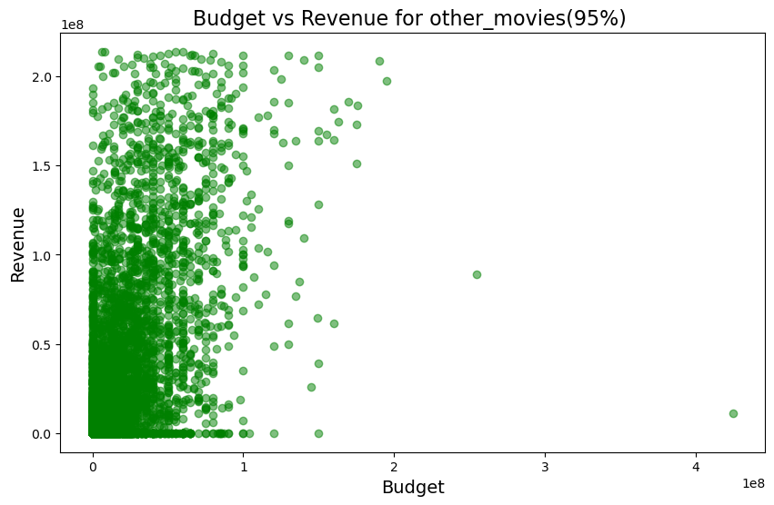

```python
# Plot the relationship between budget and revenue
plt.figure(figsize=(10, 6))
plt.scatter(other_movies['budget'], other_movies['revenue'], alpha=0.5, color='green')
plt.title('Budget vs Revenue for other_movies(95%) ', fontsize=16)
plt.xlabel('Budget', fontsize=14)
plt.ylabel('Revenue', fontsize=14)
plt.show()
```

## Summary

In this project, I worked with the TMDB Movies Dataset to analyze movie trends. The dataset contained information such as movie titles, budgets, revenues, genres, and ratings. Here’s what I did:

### Explored the Data

- Examined the dataset’s structure, basic statistics, and identified missing values.

### Cleaned the Data

- Removed unnecessary columns.
- Filled in missing values.
- Dropped rows with missing critical information.

## What I Learned

- **Data cleaning is crucial** before performing any analysis.
- **Visualizing data** makes it easier to understand trends.
- **Drama remains a favorite**, and **big budgets can lead to big earnings**.

## Final Thoughts

This project was insightful and helped me gain valuable experience in working with real-world data.

## Conclusion

After analyzing the TMDB Movies dataset, here’s what I found:

### Vote Averages

- Most movies receive **average ratings**, but there are outliers.
- Some films are **highly praised**, while others are **widely disliked**.

## Limitations of the Analysis

While this analysis provided interesting insights, there were some challenges and limitations that made drawing perfect conclusions difficult:

### Genre Splitting Was Complicated

- The `genres` column had **multiple genres listed together** (e.g., `Action|Adventure|Sci-Fi`).
- Splitting them into separate rows required **trial and error**.
- There was a chance of **incorrect splits** affecting analysis accuracy.

### Outliers in Vote Averages

- The `vote_average` column had **extremely high or low values**.
- It was difficult to determine if these were **errors or just unpopular/overhyped movies**.
- Keeping them **may have skewed** some results.

### Limited by My Coding Skills

- As a **beginner in Python and Pandas**, some tasks were challenging.
- **Splitting, exploding, and grouping data** by year and genre took a lot of research and experimentation.
- There are probably **better, more efficient methods**, but this was the best I could achieve for now. 😊